# mini project 4(country )

```python
import pandas as pd
import matplotlib.pyplot as plt
import seaborn as sns
import numpy as np
```

```python
df=pd.read_csv('C:\\Users\\Lenovo\\Downloads\\ekeeda files\\Country-data.csv')
```

```python
df
```

|  | country | child_mort | exports | health | imports | income | inflation | life_expec | total_fer | gdpp |
| --- | --- | --- | --- | --- | --- | --- | --- | --- | --- | --- |
| 0 | Afghanistan | 90.2 | 10.0 | 7.58 | 44.9 | 1610 | 9.44 | 56.2 | 5.82 | 553 |
| 1 | Albania | 16.6 | 28.0 | 6.55 | 48.6 | 9930 | 4.49 | 76.3 | 1.65 | 4090 |
| 2 | Algeria | 27.3 | 38.4 | 4.17 | 31.4 | 12900 | 16.10 | 76.5 | 2.89 | 4460 |
| 3 | Angola | 119.0 | 62.3 | 2.85 | 42.9 | 5900 | 22.40 | 60.1 | 6.16 | 3530 |
| 4 | Antigua and Barbuda | 10.3 | 45.5 | 6.03 | 58.9 | 19100 | 1.44 | 76.8 | 2.13 | 12200 |
| ... | ... | ... | ... | ... | ... | ... | ... | ... | ... | ... |
| 162 | Vanuatu | 29.2 | 46.6 | 5.25 | 52.7 | 2950 | 2.62 | 63.0 | 3.50 | 2970 |
| 163 | Venezuela | 17.1 | 28.5 | 4.91 | 17.6 | 16500 | 45.90 | 75.4 | 2.47 | 13500 |
| 164 | Vietnam | 23.3 | 72.0 | 6.84 | 80.2 | 4490 | 12.10 | 73.1 | 1.95 | 1310 |
| 165 | Yemen | 56.3 | 30.0 | 5.18 | 34.4 | 4480 | 23.60 | 67.5 | 4.67 | 1310 |
| 166 | Zambia | 83.1 | 37.0 | 5.89 | 30.9 | 3280 | 14.00 | 52.0 | 5.40 | 1460 |

167 rows × 10 columns

```python
#reading the first five dataset
df.head()
```

|  | country | child_mort | exports | health | imports | income | inflation | life_expec | total_fer | gdpp |
| --- | --- | --- | --- | --- | --- | --- | --- | --- | --- | --- |
| 0 | Afghanistan | 90.2 | 10.0 | 7.58 | 44.9 | 1610 | 9.44 | 56.2 | 5.82 | 553 |
| 1 | Albania | 16.6 | 28.0 | 6.55 | 48.6 | 9930 | 4.49 | 76.3 | 1.65 | 4090 |
| 2 | Algeria | 27.3 | 38.4 | 4.17 | 31.4 | 12900 | 16.10 | 76.5 | 2.89 | 4460 |
| 3 | Angola | 119.0 | 62.3 | 2.85 | 42.9 | 5900 | 22.40 | 60.1 | 6.16 | 3530 |
| 4 | Antigua and Barbuda | 10.3 | 45.5 | 6.03 | 58.9 | 19100 | 1.44 | 76.8 | 2.13 | 12200 |

```python
#now cheach the statistical information
df.describe()
```

|  | child_mort | exports | health | imports | income | inflation | life_expec | total_fer | gdpp |
| --- | --- | --- | --- | --- | --- | --- | --- | --- | --- |
| count | 167.000000 | 167.000000 | 167.000000 | 167.000000 | 167.000000 | 167.000000 | 167.000000 | 167.000000 | 167.000000 |
| mean | 38.270060 | 41.108976 | 6.815689 | 46.890215 | 17144.688623 | 7.781832 | 70.555689 | 2.947964 | 12964.155689 |
| std | 40.328931 | 27.412010 | 2.746837 | 24.209589 | 19278.067698 | 10.570704 | 8.893172 | 1.513848 | 18328.704809 |
| min | 2.600000 | 0.109000 | 1.810000 | 0.065900 | 609.000000 | -4.210000 | 32.100000 | 1.150000 | 231.000000 |
| 25% | 8.250000 | 23.800000 | 4.920000 | 30.200000 | 3355.000000 | 1.810000 | 65.300000 | 1.795000 | 1330.000000 |
| 50% | 19.300000 | 35.000000 | 6.320000 | 43.300000 | 9960.000000 | 5.390000 | 73.100000 | 2.410000 | 4660.000000 |
| 75% | 62.100000 | 51.350000 | 8.600000 | 58.750000 | 22800.000000 | 10.750000 | 76.800000 | 3.880000 | 14050.000000 |
| max | 208.000000 | 200.000000 | 17.900000 | 174.000000 | 125000.000000 | 104.000000 | 82.800000 | 7.490000 | 105000.000000 |

```python
#now cheach the null values in our dataset
df.isnull().sum()
```

```
country       0
child_mort    0
exports       0
health        0
imports       0
income        0
inflation     0
life_expec    0
total_fer     0
gdpp          0
dtype: int64
```

# Exploratory Data Analysis

# By plotting a spirplot, we can get a better understanding of how the data are distributed. We can also see that some of the variables have strong linear or non-linear correlations between each other. To further explore them, we'll use corr() function to generate a correlation matrix.

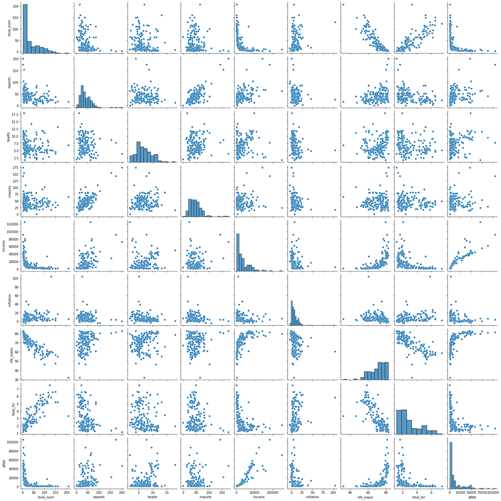

```python
sns.pairplot(df.drop("country",axis=1))
```

```python
df.drop('country',axis=1).corr()
```

|  | child_mort | exports | health | imports | income | inflation | life_expec | total_fer | gdpp |
| --- | --- | --- | --- | --- | --- | --- | --- | --- | --- |
| child_mort | 1.000000 | -0.318093 | -0.200402 | -0.127211 | -0.524315 | 0.288276 | -0.886676 | 0.848478 | -0.483032 |
| exports | -0.318093 | 1.000000 | -0.114408 | 0.737381 | 0.516784 | -0.107294 | 0.316313 | -0.320011 | 0.418725 |
| health | -0.200402 | -0.114408 | 1.000000 | 0.095717 | 0.129579 | -0.255376 | 0.210692 | -0.196674 | 0.345966 |
| imports | -0.127211 | 0.737381 | 0.095717 | 1.000000 | 0.122406 | -0.246994 | 0.054391 | -0.159048 | 0.115498 |
| income | -0.524315 | 0.516784 | 0.129579 | 0.122406 | 1.000000 | -0.147756 | 0.611962 | -0.501840 | 0.895571 |
| inflation | 0.288276 | -0.107294 | -0.255376 | -0.246994 | -0.147756 | 1.000000 | -0.239705 | 0.316921 | -0.221631 |
| life_expec | -0.886676 | 0.316313 | 0.210692 | 0.054391 | 0.611962 | -0.239705 | 1.000000 | -0.760875 | 0.600089 |
| total_fer | 0.848478 | -0.320011 | -0.196674 | -0.159048 | -0.501840 | 0.316921 | -0.760875 | 1.000000 | -0.454910 |
| gdpp | -0.483032 | 0.418725 | 0.345966 | 0.115498 | 0.895571 | -0.221631 | 0.600089 | -0.454910 | 1.000000 |

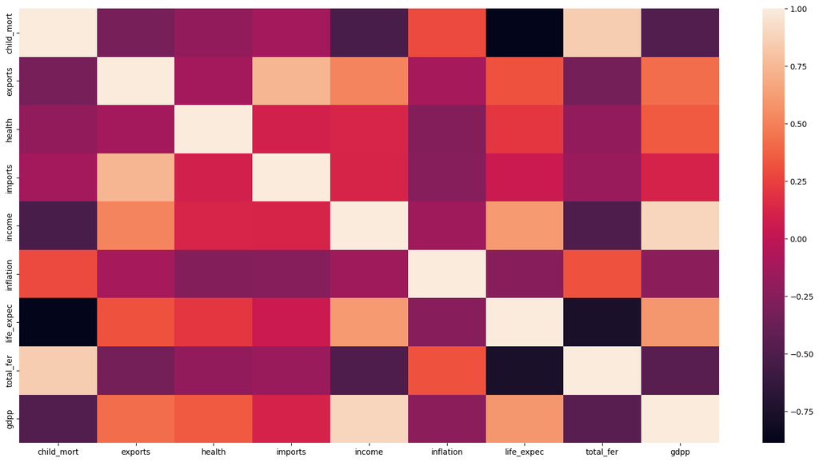

```python
plt.figure(figsize = (20,10))
sns.heatmap(df.drop('country',axis=1).corr())
```

# Checking of the outliers in each columns

```python
# Checking outliers at 25%,50%,75%,90%,95% and 99%
df.describe(percentiles=[.25,.5,.75,.90,.95,.99])
```

|  | child_mort | exports | health | imports | income | inflation | life_expec | total_fer | gdpp |
| --- | --- | --- | --- | --- | --- | --- | --- | --- | --- |
| count | 167.000000 | 167.000000 | 167.000000 | 167.000000 | 167.000000 | 167.000000 | 167.000000 | 167.000000 | 167.000000 |
| mean | 38.270060 | 41.108976 | 6.815689 | 46.890215 | 17144.688623 | 7.781832 | 70.555689 | 2.947964 | 12964.155689 |
| std | 40.328931 | 27.412010 | 2.746837 | 24.209589 | 19278.067698 | 10.570704 | 8.893172 | 1.513848 | 18328.704809 |
| min | 2.600000 | 0.109000 | 1.810000 | 0.065900 | 609.000000 | -4.210000 | 32.100000 | 1.150000 | 231.000000 |
| 25% | 8.250000 | 23.800000 | 4.920000 | 30.200000 | 3355.000000 | 1.810000 | 65.300000 | 1.795000 | 1330.000000 |
| 50% | 19.300000 | 35.000000 | 6.320000 | 43.300000 | 9960.000000 | 5.390000 | 73.100000 | 2.410000 | 4660.000000 |
| 75% | 62.100000 | 51.350000 | 8.600000 | 58.750000 | 22800.000000 | 10.750000 | 76.800000 | 3.880000 | 14050.000000 |
| 90% | 100.220000 | 70.800000 | 10.940000 | 75.420000 | 41220.000000 | 16.640000 | 80.400000 | 5.322000 | 41840.000000 |
| 95% | 116.000000 | 80.570000 | 11.570000 | 81.140000 | 48290.000000 | 20.870000 | 81.400000 | 5.861000 | 48610.000000 |
| 99% | 153.400000 | 160.480000 | 13.474000 | 146.080000 | 84374.000000 | 41.478000 | 82.370000 | 6.563600 | 79088.000000 |
| max | 208.000000 | 200.000000 | 17.900000 | 174.000000 | 125000.000000 | 104.000000 | 82.800000 | 7.490000 | 105000.000000 |

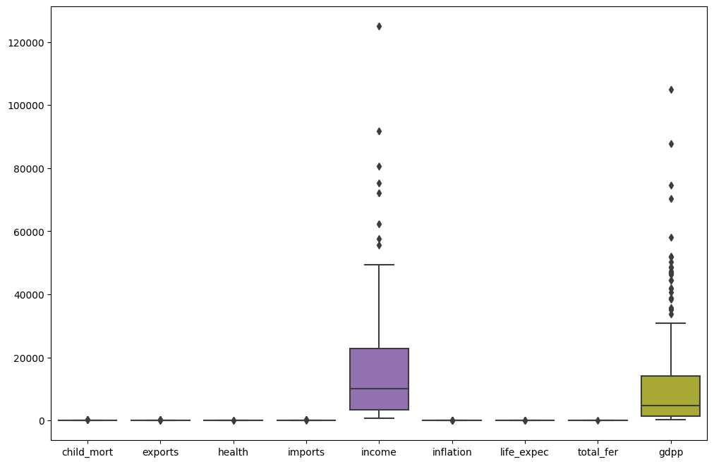

```python
fig = plt.figure(figsize = (12,8))
sns.boxplot(data=df)
plt.show()
```

# scalling the data

```python
from sklearn.preprocessing import MinMaxScaler,StandardScaler
```

```python
scale= MinMaxScaler()
scale_df=scale.fit_transform(df.drop('country',axis=1))
```

```python
country_scale_df = pd.DataFrame(data = scale_df,
                               columns=df.columns[1:])
```

```python
country_scale_df.head()
```

|  | child_mort | exports | health | imports | income | inflation | life_expec | total_fer | gdpp |
| --- | --- | --- | --- | --- | --- | --- | --- | --- | --- |
| 0 | 0.426485 | 0.049482 | 0.358608 | 0.257765 | 0.008047 | 0.126144 | 0.475345 | 0.736593 | 0.003073 |
| 1 | 0.068160 | 0.139531 | 0.294593 | 0.279037 | 0.074933 | 0.080399 | 0.871795 | 0.078864 | 0.036833 |
| 2 | 0.120253 | 0.191559 | 0.146675 | 0.180149 | 0.098809 | 0.187691 | 0.875740 | 0.274448 | 0.040365 |
| 3 | 0.566699 | 0.311125 | 0.064636 | 0.246266 | 0.042535 | 0.245911 | 0.552268 | 0.790221 | 0.031488 |
| 4 | 0.037488 | 0.227079 | 0.262275 | 0.338255 | 0.148652 | 0.052213 | 0.881657 | 0.154574 | 0.114242 |

# Principal Component Analysis¶

Pricipal Component Analysis (PCA) is a Dimensionality Reduction technique usually used in large datasets with multiple dimensions, by transforming a large set of variables into a smaller one that still contains most of the information in the original dataset.

We start the PCA by starting an instance of it using PCA() and fit it with the scaled country data. The optimal number of Principal compenent are chosen by picking the minimum number of components that demonstrates the highest amount of variance.

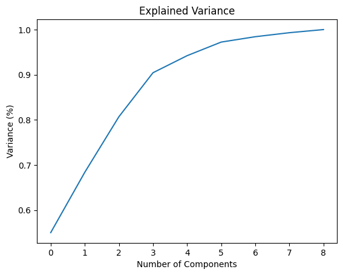

```python
from sklearn.decomposition import PCA
pca = PCA()
principalComponents = pca.fit_transform(scale_df)
plt.figure()
plt.plot(np.cumsum(pca.explained_variance_ratio_))
plt.xlabel('Number of Components')
plt.ylabel('Variance (%)') #for each component
plt.title('Explained Variance')
plt.show()
```

```python
pca = PCA(n_components=5)
new_data = pca.fit_transform(scale_df)
# This will be the new data fed to the algorithm.
principal_Df = pd.DataFrame(data = new_data
             , columns = ['principal component 1', 'principal component 2','principal component 3','principal component 4','principal component 5'])
```

```python
principal_Df
```

|  | principal component 1 | principal component 2 | principal component 3 | principal component 4 | principal component 5 |
| --- | --- | --- | --- | --- | --- |
| 0 | -0.599078 | 0.095490 | 0.157554 | -0.024333 | -0.045618 |
| 1 | 0.158474 | -0.212092 | -0.064189 | -0.061247 | 0.014191 |
| 2 | 0.003686 | -0.135867 | -0.134182 | 0.133574 | -0.091150 |
| 3 | -0.650235 | 0.275975 | -0.142672 | 0.156018 | -0.081997 |
| 4 | 0.200711 | -0.064662 | -0.100715 | -0.037902 | -0.035799 |
| ... | ... | ... | ... | ... | ... |
| 162 | -0.160078 | -0.029625 | -0.121910 | -0.066099 | -0.009043 |
| 163 | 0.061133 | -0.171339 | -0.058586 | 0.247460 | -0.093260 |
| 164 | 0.115512 | -0.032034 | -0.195243 | -0.231993 | -0.035734 |
| 165 | -0.332968 | -0.019824 | -0.029989 | 0.105416 | -0.141550 |
| 166 | -0.573897 | 0.108788 | 0.032552 | 0.044839 | 0.024088 |

167 rows × 5 columns

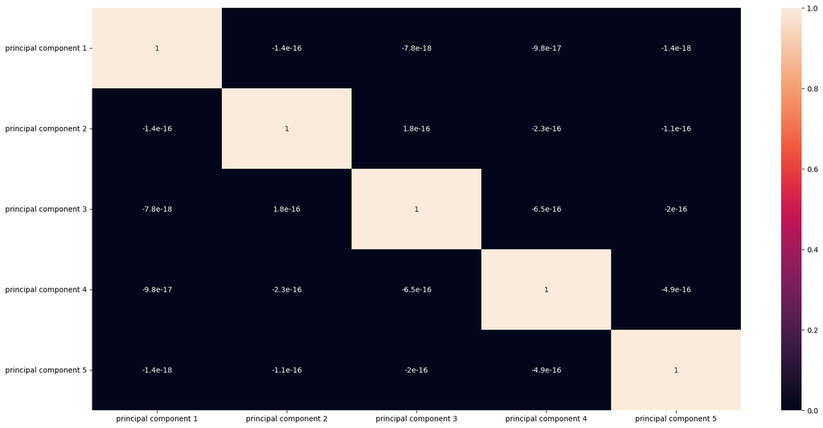

```python
plt.figure(figsize=(20,10))
sns.heatmap(principal_Df.corr(),annot = True)
```

# Checking outliers of all the principal complnents

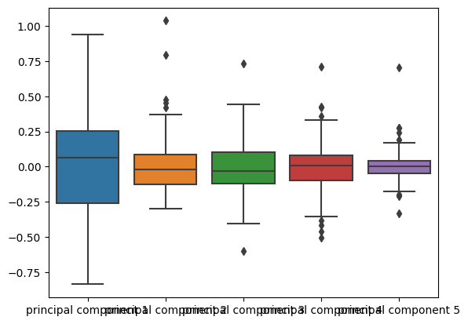

```python
sns.boxplot(data=principal_Df)
```

# Kmeans Clustering

```python
from random import sample
from numpy.random import uniform
import numpy as np
from math import isnan
from sklearn.cluster import KMeans
from sklearn.neighbors import NearestNeighbors
k_means = KMeans(n_clusters=4, random_state=42)

k_means.fit(principal_Df)
```

```
KMeans(n_clusters=4, random_state=42)
```

```python
# model parameter study
k_means.cluster_centers_
```

```
array([[ 8.24881994e-02, -1.07889244e-01, -7.36415819e-02,
        -2.94709175e-02,  4.39175788e-04],
       [ 4.54318159e-01,  9.12873781e-02,  1.78951954e-01,
         1.02299825e-01,  1.27747596e-02],
       [-5.02421179e-01,  9.78690809e-02,  4.72259900e-02,
         6.81308797e-03, -6.51057622e-03],
       [ 7.40955974e-01,  7.51218129e-01, -3.53498319e-01,
        -2.62985350e-01, -4.08012509e-02]])
```

```python
k_means.inertia_
```

```
14.337590232281666
```

The lesser the model inertia, the better the model fit. We can see that the model has very less inertia. So, this is good model fit to the data.

```python
# define a dictionary that contains all of our relevant info.
results = []

# define how many clusters we want to test up to.
num_of_clusters = 10

# run through each instance of K
for k in range(2, num_of_clusters):

    print("-"*100)

    # create an instance of the model, and fit the training data to it.
    kmeans = KMeans(n_clusters=k, random_state=0).fit(principal_Df)


    # store the different metrics
#     results_dict_pca[k]['silhouette_score'] = sil_score
#     results_dict_pca[k]['inertia'] = kmeans.inertia_
#     results_dict_pca[k]['score'] = kmeans.score
#     results_dict_pca[k]['model'] = kmeans

    results.append(kmeans.inertia_)

    # print the results
    print("Number of Clusters: {}".format(k),kmeans.inertia_)
```

```
----------------------------------------------------------------------------------------------------
Number of Clusters: 2 23.47467379884149
----------------------------------------------------------------------------------------------------
Number of Clusters: 3 16.88315171102062
----------------------------------------------------------------------------------------------------
Number of Clusters: 4 14.337590232281666
----------------------------------------------------------------------------------------------------
Number of Clusters: 5 12.601899387317557
----------------------------------------------------------------------------------------------------
Number of Clusters: 6 11.35811212662246
----------------------------------------------------------------------------------------------------
Number of Clusters: 7 10.19156176282237
----------------------------------------------------------------------------------------------------
Number of Clusters: 8 9.430103098061998
----------------------------------------------------------------------------------------------------
Number of Clusters: 9 8.61195262854716
```